# Part I

## Ford GoBike Exploration

### Introduction

This document explores a dataset containing information about individual rides made in a bike-sharing system covering the greater San Francisco Bay area.

```python
# import libraries
import pandas as pd
import numpy as np
import matplotlib.pyplot as plt
import seaborn as sns
```

```python
# Load our data with pandas
ford_bikes = pd.read_csv("201902-fordgobike-tripdata.csv")
```

```python
# High level data overview

print(ford_bikes.shape)
print(ford_bikes.dtypes)
print(ford_bikes.head(10))
```

```
(183412, 16)
duration_sec                 int64
start_time                  object
end_time                    object
start_station_id           float64
start_station_name          object
start_station_latitude     float64
start_station_longitude    float64
end_station_id             float64
end_station_name            object
end_station_latitude       float64
end_station_longitude      float64
bike_id                      int64
user_type                   object
member_birth_year          float64
member_gender               object
bike_share_for_all_trip     object
dtype: object
   duration_sec                start_time                  end_time  \
0         52185  2019-02-28 17:32:10.1450  2019-03-01 08:01:55.9750
1         42521  2019-02-28 18:53:21.7890  2019-03-01 06:42:03.0560
2         61854  2019-02-28 12:13:13.2180  2019-03-01 05:24:08.1460
3         36490  2019-02-28 17:54:26.0100  2019-03-01 04:02:36.8420
4          1585  2019-02-28 23:54:18.5490  2019-03-01 00:20:44.0740
5          1793  2019-02-28 23:49:58.6320  2019-03-01 00:19:51.7600
6          1147  2019-02-28 23:55:35.1040  2019-03-01 00:14:42.5880
7          1615  2019-02-28 23:41:06.7660  2019-03-01 00:08:02.7560
8          1570  2019-02-28 23:41:48.7900  2019-03-01 00:07:59.7150
9          1049  2019-02-28 23:49:47.6990  2019-03-01 00:07:17.0250

   start_station_id                                start_station_name  \
0              21.0  Montgomery St BART Station (Market St at 2nd St)
1              23.0                     The Embarcadero at Steuart St
2              86.0                           Market St at Dolores St
3             375.0                           Grove St at Masonic Ave
4               7.0                               Frank H Ogawa Plaza
5              93.0                      4th St at Mission Bay Blvd S
6             300.0                              Palm St at Willow St
7              10.0                        Washington St at Kearny St
8              10.0                        Washington St at Kearny St
```

[output cut: 34 more lines]

```
7            -122.421025     6329  Subscriber             1989.0
8            -122.421025     6548  Subscriber             1988.0
9            -122.421339     6488  Subscriber             1992.0

  member_gender bike_share_for_all_trip
0          Male                      No
1           NaN                      No
2          Male                      No
3         Other                      No
4          Male                     Yes
5          Male                      No
6        Female                      No
7          Male                      No
8         Other                      No
9          Male                      No
```

```python
# descriptive analysis
print(ford_bikes.describe())
```

```
        duration_sec  start_station_id  start_station_latitude  \
count  183412.000000     183215.000000           183412.000000
mean      726.078435        138.590427               37.771223
std      1794.389780        111.778864                0.099581
min        61.000000          3.000000               37.317298
25%       325.000000         47.000000               37.770083
50%       514.000000        104.000000               37.780760
75%       796.000000        239.000000               37.797280
max     85444.000000        398.000000               37.880222

       start_station_longitude  end_station_id  end_station_latitude  \
count            183412.000000   183215.000000         183412.000000
mean               -122.352664      136.249123             37.771427
std                   0.117097      111.515131              0.099490
min                -122.453704        3.000000             37.317298
25%                -122.412408       44.000000             37.770407
50%                -122.398285      100.000000             37.781010
75%                -122.286533      235.000000             37.797320
max                -121.874119      398.000000             37.880222

       end_station_longitude        bike_id  member_birth_year
count          183412.000000  183412.000000      175147.000000
mean             -122.352250    4472.906375        1984.806437
std                 0.116673    1664.383394          10.116689
min              -122.453704      11.000000        1878.000000
25%              -122.411726    3777.000000        1980.000000
50%              -122.398279    4958.000000        1987.000000
75%              -122.288045    5502.000000        1992.000000
max              -121.874119    6645.000000        2001.000000
```

## Insights in our data

- Data contains 183412 rows, 16 columns

```python
# check all types of categorization in the categorical variables
ford_bikes[['member_gender', 'bike_share_for_all_trip', 'user_type']].value_counts()
```

```
member_gender  bike_share_for_all_trip  user_type
Male           No                       Subscriber    106011
Female         No                       Subscriber     32597
Male           Yes                      Subscriber     13111
               No                       Customer       11529
Female         No                       Customer        4647
               Yes                      Subscriber      3600
Other          No                       Subscriber      2549
               Yes                      Subscriber       648
               No                       Customer         455
dtype: int64
```

```python
ford_bikes.columns
```

```
Index(['duration_sec', 'start_time', 'end_time', 'start_station_id',
       'start_station_name', 'start_station_latitude',
       'start_station_longitude', 'end_station_id', 'end_station_name',
       'end_station_latitude', 'end_station_longitude', 'bike_id', 'user_type',
       'member_birth_year', 'member_gender', 'bike_share_for_all_trip'],
      dtype='object')
```

```python
# Check for possible duplicates
ford_bikes.loc[ford_bikes.duplicated(keep=False), :]
```

|  | duration_sec | start_time | end_time | start_station_id | start_station_name | start_station_latitude | start_station_longitude | end_station_id | end_station_name | end_station_latitude | end_station_longitude | bike_id | user_type | member_birth_year | member_gender | bike_share_for_all_trip |
| --- | --- | --- | --- | --- | --- | --- | --- | --- | --- | --- | --- | --- | --- | --- | --- | --- |

## Define

#### 1) check and drop the rows with missing data

#### Code

```python
ford_bikes.isnull().sum()
```

```
duration_sec                  0
start_time                    0
end_time                      0
start_station_id            197
start_station_name          197
start_station_latitude        0
start_station_longitude       0
end_station_id              197
end_station_name            197
end_station_latitude          0
end_station_longitude         0
bike_id                       0
user_type                     0
member_birth_year          8265
member_gender              8265
bike_share_for_all_trip       0
dtype: int64
```

```python
# drop rows with missing data in the specific columns
ford_bikes.dropna(axis=0, subset=['start_station_id', 'start_station_name', 'end_station_id',
                                 'start_station_name', 'member_birth_year', 'member_gender'], inplace=True)
```

#### Test

```python
ford_bikes.isnull().sum()
```

```
duration_sec               0
start_time                 0
end_time                   0
start_station_id           0
start_station_name         0
start_station_latitude     0
start_station_longitude    0
end_station_id             0
end_station_name           0
end_station_latitude       0
end_station_longitude      0
bike_id                    0
user_type                  0
member_birth_year          0
member_gender              0
bike_share_for_all_trip    0
dtype: int64
```

### 2) Incorrect Data types

#### Define

##### Change all columns with incorrect data types to the right data types

#### Code

```python
ford_bikes = ford_bikes.astype({'start_station_id': str, 'end_station_id': str, 'bike_id': str, 'member_birth_year': int})
```

```python
# Change the time columns from object to datetime
ford_bikes[['start_time','end_time']] = ford_bikes[['start_time','end_time']].apply(pd.to_datetime)
```

#### Test

```python
ford_bikes.info()
```

```
<class 'pandas.core.frame.DataFrame'>
Int64Index: 174952 entries, 0 to 183411
Data columns (total 16 columns):
 #   Column                   Non-Null Count   Dtype
---  ------                   --------------   -----
 0   duration_sec             174952 non-null  int64
 1   start_time               174952 non-null  datetime64[ns]
 2   end_time                 174952 non-null  datetime64[ns]
 3   start_station_id         174952 non-null  object
 4   start_station_name       174952 non-null  object
 5   start_station_latitude   174952 non-null  float64
 6   start_station_longitude  174952 non-null  float64
 7   end_station_id           174952 non-null  object
 8   end_station_name         174952 non-null  object
 9   end_station_latitude     174952 non-null  float64
 10  end_station_longitude    174952 non-null  float64
 11  bike_id                  174952 non-null  object
 12  user_type                174952 non-null  object
 13  member_birth_year        174952 non-null  int32
 14  member_gender            174952 non-null  object
 15  bike_share_for_all_trip  174952 non-null  object
dtypes: datetime64[ns](2), float64(4), int32(1), int64(1), object(8)
memory usage: 22.0+ MB
```

### Code

```python
### Further create a Day, month, hour category from the time and year column options

ford_bikes['start_day'] = ford_bikes['start_time'].dt.day_name()
ford_bikes['start_month'] = ford_bikes['start_time'].dt.month_name()

# bike['start_year'] = bike['start_time'].dt.year
ford_bikes['start_hour'] = ford_bikes['start_time'].dt.hour
ford_bikes['start_hour'] = ford_bikes.start_hour.astype(str)


ford_bikes['end_day'] = ford_bikes['end_time'].dt.day_name()
ford_bikes['end_month'] = ford_bikes['end_time'].dt.month_name()
ford_bikes['end_hour'] = ford_bikes['end_time'].dt.hour
ford_bikes['end_hour'] = ford_bikes.end_hour.astype(str)
```

### Test

```python
ford_bikes.columns
```

```
Index(['duration_sec', 'start_time', 'end_time', 'start_station_id',
       'start_station_name', 'start_station_latitude',
       'start_station_longitude', 'end_station_id', 'end_station_name',
       'end_station_latitude', 'end_station_longitude', 'bike_id', 'user_type',
       'member_birth_year', 'member_gender', 'bike_share_for_all_trip',
       'start_day', 'start_month', 'start_hour', 'end_day', 'end_month',
       'end_hour'],
      dtype='object')
```

# Questions

### What is the structure of the dataset?

- There are 183412 rows and 16 features ('duration_sec', 'start_time', 'end_time', 'start_station_id','start_station_name', 'start_station_latitude','start_station_longitude', 'end_station_id', 'end_station_name','end_station_latitude', 'end_station_longitude', 'bike_id', 'user_type','member_birth_year', 'member_gender', 'bike_share_for_all_trip')

### What is/are the main feature(s) of interest?

- Average length of each trip
- Type of subscribers
- Gender of members or other variables and how they influence other variables

### What are features of the data set will help support your investigation with respect to the feature of interest.

- From a glance, i see the gender, birth year, duration, time, and date as features that would uncover some insights on the process and the behaviour of users on the bike sharing system.

# Univariate Exploration

#### 1) What is the percentage of members that are registered on the Ford Bikers system?

```python
ford_bikes['member_gender'].value_counts()
```

```
Male      130500
Female     40805
Other       3647
Name: member_gender, dtype: int64
```

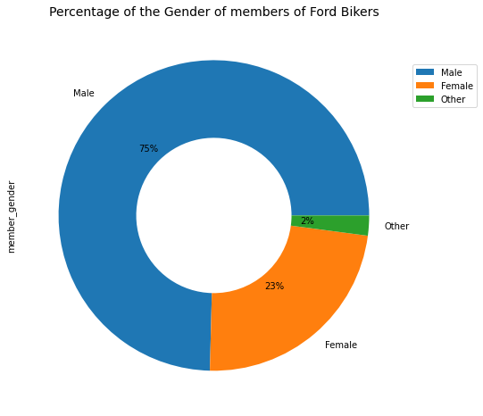

```python
gender = ford_bikes.member_gender.value_counts()
gender.plot(kind='pie', figsize=(8,8), wedgeprops={'width':0.5}, autopct='%1.0f%%');
plt.title('Percentage of the Gender of members of Ford Bikers', size=14);
plt.legend(bbox_to_anchor=(1, 0.9), loc='upper left');
```

#### 2) What is the number of different user types on the Ford Bikers system?

```python
ford_bikes['user_type'].value_counts()
```

```
Subscriber    158386
Customer       16566
Name: user_type, dtype: int64
```

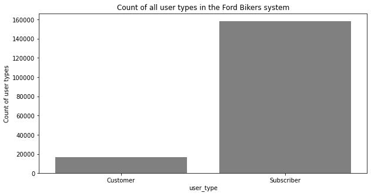

```python
users = ford_bikes['user_type'].value_counts().index
plt.figure(figsize=(10,5))
sns.countplot(data=ford_bikes, x='user_type', color='grey')
plt.ylabel('Count of user types')
plt.xlabel('user_type')
plt.title('Count of all user types in the Ford Bikers system');
```

#### What is the distribution of the duration of each trip?

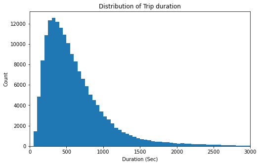

```python
binsize = 50
bins = np.arange(50, ford_bikes['duration_sec'].max()+binsize, binsize)

plt.figure(figsize=[8, 5])
plt.hist(data = ford_bikes, x = 'duration_sec', bins=bins)
plt.xlabel('Duration (Sec)')
plt.ylabel('Count')
plt.title('Distribution of Trip duration');
plt.xlim([0, 3000]);
```

#### 3) What is the age distribution of Ford GoBike customer?

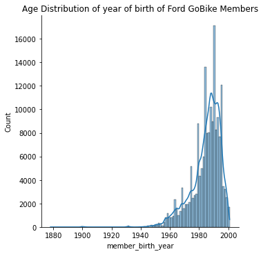

```python
sns.displot(data = ford_bikes,
            x = 'member_birth_year', kde=True, bins=100).set(title='Age Distribution of year of birth of Ford GoBike Members');
```

### The member birth year gives us an idea of the distribution but not very intuitive, we convert to age

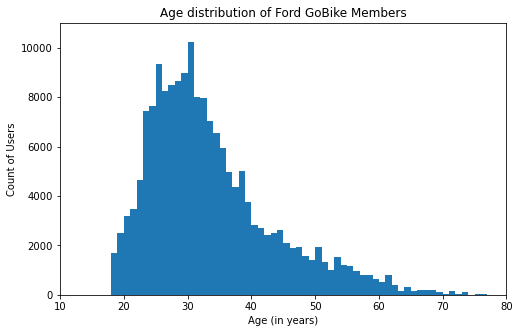

```python
# Plot a new viz of age distribution from Members Year of Birth Column

binsize = 1
bins = np.arange(0, ford_bikes['member_birth_year'].astype(float).max()+binsize, binsize)

plt.figure(figsize=[8, 5])
plt.hist(data = ford_bikes, x = 'member_birth_year', bins = bins);
plt.axis([1939, 2009, 0, 11000])
plt.xticks([1939, 1949, 1959, 1969, 1979, 1989, 1999, 2009], [(2019-1939), (2019-1949), (2019-1959), (2019-1969), (2019-1979), (2019-1989), (2019-1999), (2019-2009)])
plt.gca().invert_xaxis()
plt.xlabel('Age (in years)')
plt.ylabel('Count of Users')
plt.title('Age distribution of Ford GoBike Members');
```

#### We see a distribution slighly skewed to the right with alot of observations within ages 19-45 for the members.

#### 4) How is the data of Members distributed with respect to time (day, month, year)

```python
# convert day, and hour into ordered categorical types
ordinal_dict = {'start_day': ['Monday','Tuesday','Wednesday','Thursday','Friday', 'Saturday', 'Sunday'],
                    'end_day': ['Monday','Tuesday','Wednesday','Thursday','Friday', 'Saturday', 'Sunday'],
                   'start_hour': [str(x) for x in range(0,24)],
                   'end_hour': [str(x) for x in range(0,24)]}

for var in ordinal_dict:
    ordered_var = pd.api.types.CategoricalDtype(ordered = True,
                                                categories = ordinal_dict[var])
    ford_bikes[var] = ford_bikes[var].astype(ordered_var)
```

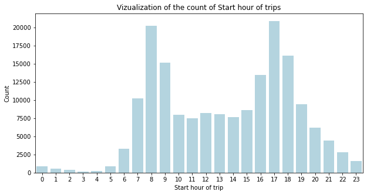

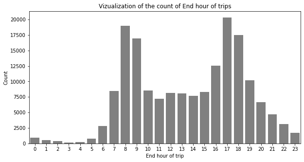

```python
plt.figure(figsize=(10,5))
sns.countplot(data=ford_bikes, x='start_hour', color='lightblue')
plt.ylabel('Count')
plt.xlabel('Start hour of trip')
plt.title('Vizualization of the count of Start hour of trips');


plt.figure(figsize=(10,5))
sns.countplot(data=ford_bikes, x='end_hour', color='grey')
plt.ylabel('Count')
plt.xlabel('End hour of trip')
plt.title('Vizualization of the count of End hour of trips');
```

#### 5) What day of the week has the highest start and end trips by members

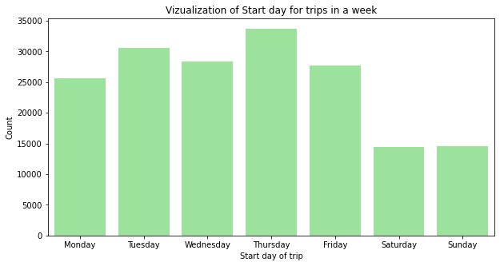

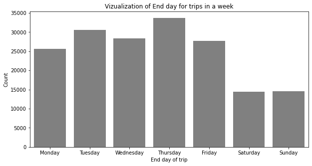

```python
plt.figure(figsize=(10,5))
sns.countplot(data=ford_bikes, x='start_day', color='lightgreen')
plt.ylabel('Count')
plt.xlabel('Start day of trip')
plt.title('Vizualization of Start day for trips in a week');


plt.figure(figsize=(10,5))
sns.countplot(data=ford_bikes, x='end_day', color='grey')
plt.ylabel('Count')
plt.xlabel('End day of trip')
plt.title('Vizualization of End day for trips in a week');
```

#### Insights

- We observe Tuesdays and Thursdays are the highest days for trips to begin and end...
- Saturdays and Sundays are the least days for both perhaps because there's less commuting since it is a weekend.

#### 6) What is the frequency of riders who share rides on different trips

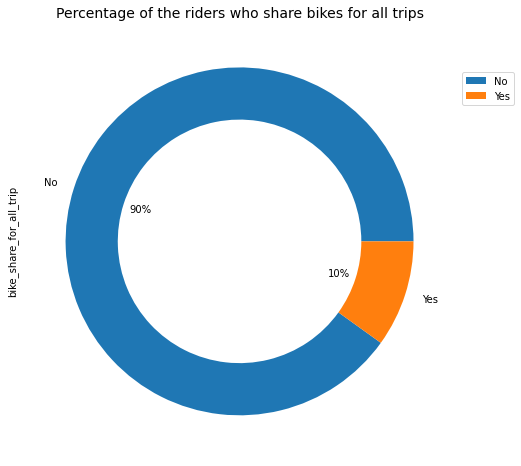

```python
sharing = ford_bikes.bike_share_for_all_trip.value_counts()
sharing.plot(kind='pie', figsize=(8,8), wedgeprops={'width':0.3}, autopct='%1.0f%%');
plt.title('Percentage of the riders who share bikes for all trips', size=14);
plt.legend(bbox_to_anchor=(1, 0.9), loc='upper left');
```

# Bivariate Exploration

#### 7) What is the relationship between member gender and the length of their travels?

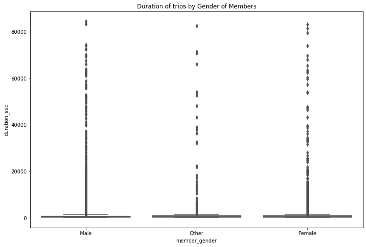

```python
plt.figure(figsize=(12,8))
plt.title('Duration of trips by Gender of Members')
sns.boxplot(data=ford_bikes, x = 'member_gender', y='duration_sec', color = base_color);
```

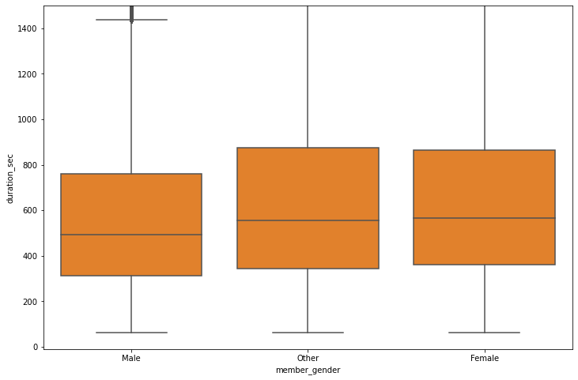

```python
# We reduce the max limit of y-axis to see the distinction in the visualization

plt.figure(figsize=(12,8))
base_color = sns.color_palette()[1]
plt.ylim([-10, 1500])
plt.xlabel('Gender of Members')
plt.ylabel('Duration (sec)')
sns.boxplot(data=ford_bikes, x = 'member_gender', y='duration_sec', color = base_color);
```

##### We see that Female/Other Gender travel longer trips than Male members.

#### 8) How does travel duration vary between user types

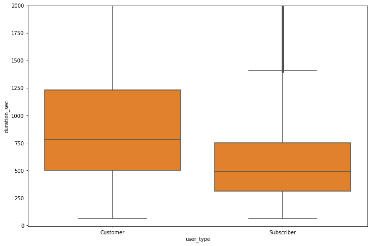

```python
plt.figure(figsize=(12,8))
base_color = sns.color_palette()[1]
plt.ylim([-10, 2000])
plt.xlabel('User Type')
plt.ylabel('Duration in (sec)')
sns.boxplot(data=ford_bikes, x = 'user_type', y='duration_sec', color = base_color);
```

#### We observe that the "Customer" User type category take longer trips than the "subscriber" type.

#### 9) What is the relationship between user type and member's gender?

[figure not shown]

```python
plt.figure(figsize = [8, 8])
plt.title('Number of each gender that are subscribed to different user type plans')
sns.countplot(data = ford_bikes, x = 'user_type', hue = 'member_gender')
plt.legend(bbox_to_anchor=(1, 0.9), loc='upper left');
plt.show()
```

#### 15) What is the correlation relationship of the numeric variables?

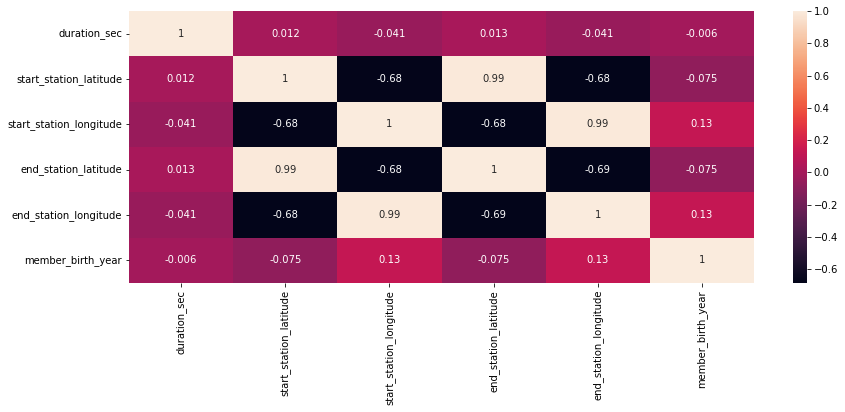

```python
plt.figure(figsize=(14,5))
sns.heatmap(ford_bikes.corr(), annot=True);
```

#### The columns worthy of comparisons are duration time and birth year and we see there's no correlation between them.

#### 10) What is the count of different User types who share bikes for all trips?

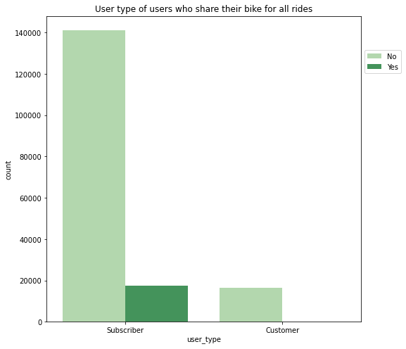

```python
plt.figure(figsize = [8, 8])
sns.countplot(data = ford_bikes, x = 'user_type', hue = 'bike_share_for_all_trip',
              order=ford_bikes.user_type.value_counts().index,
             palette = 'Greens')
plt.title("User type of users who share their bike for all rides")
plt.legend(bbox_to_anchor=(1, 0.9), loc='upper left');
```

#### Only Subscribers seem to share bikes for all trips

#### 11) How does the user type riders vary within each day?

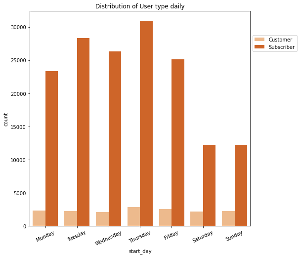

```python
plt.figure(figsize = [8, 8])
sns.countplot(data = ford_bikes, x = 'start_day', hue = 'user_type', palette = 'Oranges');
plt.title("Distribution of User type daily")
plt.legend(bbox_to_anchor=(1, 0.9), loc='upper left');
plt.xticks(rotation=25);
```

#### There are more Subscribers than Customers on every day of the week; there are more Subscribers taking trips on Thursdays.